# RNA-seq Analysis of iPSC-Derived Neural Progenitors in Autism Spectrum Disorder (ASD probands vs controls)

Andrea Attura, Alina Iuferova

2024-05-29

# 1 Package installation

> Run this section only once, the first time you set up the environment. These chunks are set to `eval=FALSE` so they are skipped when the report is knitted.

```r
if (!requireNamespace("BiocManager", quietly = TRUE))
    install.packages("BiocManager")

BiocManager::install(c(
  "recount3", "edgeR", "limma", "EDASeq", "SummarizedExperiment",
  "org.Hs.eg.db", "TxDb.Hsapiens.UCSC.hg19.knownGene",
  "clusterProfiler", "pathview", "ReactomePA", "enrichplot"
))
install.packages(c("ggplot2", "ggfortify", "dplyr", "corrplot",
                   "knitr", "readxl", "pheatmap", "cluster"))
```

# 2 Libraries

```r
library(recount3)
library(edgeR)
library(limma)
library(EDASeq)
library(SummarizedExperiment)
library(org.Hs.eg.db)
library(AnnotationDbi)
library(ggplot2)
library(ggfortify)
library(dplyr)
library(corrplot)
library(knitr)
library(readxl)
library(pheatmap)
library(cluster)
library(clusterProfiler)
library(enrichplot)
```

# 3 Introduction

This notebook analyses the RNA-seq data of the study **Mariani et al., 2015, *Cell*, “FOXG1-Dependent Dysregulation of GABA/Glutamate Neuron Differentiation in Autism Spectrum Disorders”** (SRA study `SRP047194`), re-processed by recount3.

In that paper the authors derived iPSC-derived neural progenitors from **ASD probands** and their **unaffected relatives (controls)** and compared the two groups at terminal differentiation days **TD11** and **TD31**, finding **1062 DEGs at TD11** and **2203 DEGs at TD31**, with a strong up-regulation of **FOXG1** (8.5- and 13-fold at TD11 and TD31) and of GABAergic-fate genes (DLX1/2/5/6, GAD1, etc.).

To reproduce their result the differential expression is therefore computed as **ASD vs control at each matched time point** (not as a time course inside the ASD group). Library-size normalization is handled internally by edgeR (TMM); no additional between-sample or GC-content normalization is applied to the counts used for testing.

# 4 Data

Loading the gene-level counts of `SRP047194` from recount3.

```r
human_projects <- available_projects()

proj_info <- subset(
  human_projects,
  project == "SRP047194" & project_type == "data_sources"
)

## RangedSummarizedExperiment (RSE) at the gene level
rse <- create_rse(proj_info)
rse
```

```
## class: RangedSummarizedExperiment
## dim: 63856 48
## metadata(8): time_created recount3_version ... annotation recount3_url
## assays(1): raw_counts
## rownames(63856): ENSG00000278704.1 ENSG00000277400.1 ...
##   ENSG00000182484.15_PAR_Y ENSG00000227159.8_PAR_Y
## rowData names(10): source type ... havana_gene tag
## colnames(48): SRR1576468 SRR1576469 ... SRR1576512 SRR1576513
## colData names(175): rail_id external_id ...
##   recount_pred.curated.cell_line BigWigURL
```

## 4.1 Sample annotation (group and differentiation day)

We parse `sra.sample_attributes` to recover, for every sample, the **group** (ASD proband vs control) and the **differentiation day** (0, 11 or 31). Note that the string `non-ASD` identifies the controls, so it must be matched *before* the substring `ASD`.

```r
attr_str <- as.character(colData(rse)$sra.sample_attributes)

# group: controls are labelled "non-ASD"
group <- ifelse(grepl("non-ASD", attr_str), "control", "ASD")
group <- factor(group, levels = c("control", "ASD"))   # control = reference

# day: extract the integer after "day "
day_num <- sub(".*day[ ]*([0-9]+).*", "\\1", attr_str)
day <- factor(paste0("d", day_num), levels = c("d0", "d11", "d31"))

# store back into the object
colData(rse)$group <- group
colData(rse)$day   <- day

table(group, day)
```

```
##          day
## group     d0 d11 d31
##   control  3  12  13
##   ASD      3   9   8
```

The contingency table above shows how many samples fall in each group x day combination; the ASD-vs-control comparison will be run within TD11 and within TD31.

# 5 Clinical data of the patients (exploratory)

We load the supplementary clinical table `mmc2.xlsx` from the paper.

```r
# Path is relative to the project root so the notebook is portable
# (keep the file under "data/mmc2/mmc2.xlsx" in the repository).
mmc2 <- read_excel(file.path("data", "mmc2", "mmc2.xlsx"), skip = 1)
mmc2 <- mmc2[!is.na(mmc2$`Subject  ID`) == TRUE, ]
head(mmc2)
```

```
## # A tibble: 6 × 23
##   `Subject  ID`               Gender `AGE AT BIOPSY (MO)` HC  (cm) at biopsy t…¹
##   <chr>                       <chr>  <chr>                <chr>
## 1 Proband                 03… Male   94                   54.5
## 2 Proband                 07… Male   76                   60.5
## 3 Proband                 11… Male   118                  56.7
## 4 Proband                 11… Male   188                  62.7
## 5 Father   03-01              Male   513                  60.5
## 6 Mother    03-02             Female 522                  57.25
## # ℹ abbreviated name: ¹`HC  (cm) at biopsy time`
## # ℹ 19 more variables: `HC  (percentile) at biopsy time` <chr>,
## #   `HC  (standard deviation) at biopsy time` <chr>,
## #   `AGE AT ASSESSMENT (MO)` <chr>, `IQ MEASURE` <chr>, `VERBAL IQ` <chr>,
## #   `NONVERBAL IQ` <chr>, `ADOS MODULE` <chr>, `ADOS SEVERITY SCORE` <chr>,
## #   `VBAS COMM SS` <chr>, `VBAS SOCIAL SS` <chr>, `VBAS DLS SS` <chr>,
## #   `iPSC name` <chr>, `Fibroblast WGS` <chr>, `Fibroblast RNASeq` <chr>, …
```

Several numeric columns are imported as character; we convert them to numeric.

```r
for (col in colnames(mmc2)) {
  if (is.character(mmc2[[col]]) && all(grepl("^-?[0-9.]+$", mmc2[[col]]))) {
    mmc2[[col]] <- as.numeric(mmc2[[col]])
  }
}
summary(mmc2)
```

```
##     Subject  ID       Gender   AGE AT BIOPSY (MO) HC  (cm) at biopsy time
##  Length   :12   Length   :12   Min.   : 76.0      Min.   :54.50
##  N.unique :12   N.unique : 2   1st Qu.:112.0      1st Qu.:56.25
##  N.blank  : 0   N.blank  : 0   Median :517.5      Median :59.25
##  Min.nchar:14   Min.nchar: 4   Mean   :379.9      Mean   :58.66
##  Max.nchar:31   Max.nchar: 6   3rd Qu.:556.8      3rd Qu.:60.85
##                                Max.   :664.0      Max.   :62.70
##  HC  (percentile) at biopsy time HC  (standard deviation) at biopsy time
##  Length   :12                    Length   :12
##  N.unique : 2                    N.unique : 4
##  N.blank  : 0                    N.blank  : 0
##  Min.nchar: 4                    Min.nchar: 4
##  Max.nchar: 6                    Max.nchar: 4
##  NAs      : 8                    NAs      : 8
##  AGE AT ASSESSMENT (MO)     IQ MEASURE     VERBAL IQ     NONVERBAL IQ
##  Length   :12           Length   :12   Length   :12   Length   :12
##  N.unique : 5           N.unique : 3   N.unique : 5   N.unique : 5
##  N.blank  : 0           N.blank  : 0   N.blank  : 0   N.blank  : 0
##  Min.nchar: 2           Min.nchar: 2   Min.nchar: 2   Min.nchar: 2
##  Max.nchar: 3           Max.nchar: 4   Max.nchar: 3   Max.nchar: 3
##
##     ADOS MODULE ADOS SEVERITY SCORE    VBAS COMM SS   VBAS SOCIAL SS
##  Length   :12   Length   :12        Length   :12    Length   :12
##  N.unique : 3   N.unique : 3        N.unique : 5    N.unique : 5
##  N.blank  : 0   N.blank  : 0        N.blank  : 0    N.blank  : 0
##  Min.nchar: 1   Min.nchar: 1        Min.nchar: 2    Min.nchar: 2
##  Max.nchar: 2   Max.nchar: 2        Max.nchar: 2    Max.nchar: 2
##
##     VBAS DLS SS     iPSC name    Fibroblast WGS Fibroblast RNASeq
##  Length   :12   Length   :12   Length   :12     Length   :12
##  N.unique : 5   N.unique :12   N.unique : 1     N.unique : 2
##  N.blank  : 0   N.blank  : 0   N.blank  : 0     N.blank  : 0
##  Min.nchar: 2   Min.nchar: 8   Min.nchar: 3     Min.nchar: 2
##  Max.nchar: 2   Max.nchar:14   Max.nchar: 3     Max.nchar: 3
##
##     iPSC RNASeq    NPC  RNASeq       ...21          ...22         NPC  ICC
##  Length   :12   Length   :12   Length   :12   Length   :12   Length   :12
##  N.unique : 1   N.unique : 2   N.unique : 2   N.unique : 2   N.unique : 2
##  N.blank  : 0   N.blank  : 0   N.blank  : 0   N.blank  : 0   N.blank  : 0
##  Min.nchar: 3   Min.nchar: 2   Min.nchar: 2   Min.nchar: 2   Min.nchar: 2
##  Max.nchar: 3   Max.nchar: 3   Max.nchar: 3   Max.nchar: 3   Max.nchar: 3
##
```

```r
vars <- mmc2[!is.na(mmc2$`HC  (percentile) at biopsy time`) == TRUE, ]
for (col in colnames(vars)) {
  if (is.character(vars[[col]]) && all(grepl("^-?[0-9.]+$", vars[[col]]))) {
    vars[[col]] <- as.numeric(vars[[col]])
  }
}
summary(vars)
```

```
##     Subject  ID       Gender  AGE AT BIOPSY (MO) HC  (cm) at biopsy time
##  Length   : 4   Length   :4   Min.   : 76.0      Min.   :54.50
##  N.unique : 4   N.unique :1   1st Qu.: 89.5      1st Qu.:56.15
##  N.blank  : 0   N.blank  :0   Median :106.0      Median :58.60
##  Min.nchar:29   Min.nchar:4   Mean   :119.0      Mean   :58.60
##  Max.nchar:31   Max.nchar:4   3rd Qu.:135.5      3rd Qu.:61.05
##                               Max.   :188.0      Max.   :62.70
##  HC  (percentile) at biopsy time HC  (standard deviation) at biopsy time
##  Length   :4                     Min.   :1.390
##  N.unique :2                     1st Qu.:1.420
##  N.blank  :0                     Median :1.460
##  Min.nchar:4                     Mean   :1.475
##  Max.nchar:6                     3rd Qu.:1.515
##                                  Max.   :1.590
##  AGE AT ASSESSMENT (MO)     IQ MEASURE   VERBAL IQ      NONVERBAL IQ
##  Min.   : 56.0          Length   :4    Min.   : 25.0   Min.   : 25.00
##  1st Qu.: 81.5          N.unique :2    1st Qu.: 77.5   1st Qu.: 67.75
##  Median :100.0          N.blank  :0    Median :100.0   Median : 84.00
##  Mean   :108.5          Min.nchar:3    Mean   : 83.0   Mean   : 75.00
##  3rd Qu.:127.0          Max.nchar:4    3rd Qu.:105.5   3rd Qu.: 91.25
##  Max.   :178.0                         Max.   :107.0   Max.   :107.00
##   ADOS MODULE ADOS SEVERITY SCORE  VBAS COMM SS   VBAS SOCIAL SS
##  Min.   :1    Min.   : 9.0        Min.   :62.00   Min.   :52.00
##  1st Qu.:1    1st Qu.: 9.0        1st Qu.:71.75   1st Qu.:55.75
##  Median :2    Median : 9.5        Median :80.00   Median :59.00
##  Mean   :2    Mean   : 9.5        Mean   :78.50   Mean   :62.50
##  3rd Qu.:3    3rd Qu.:10.0        3rd Qu.:86.75   3rd Qu.:65.75
##  Max.   :3    Max.   :10.0        Max.   :92.00   Max.   :80.00
##   VBAS DLS SS        iPSC name    Fibroblast WGS Fibroblast RNASeq
##  Min.   :57.00   Length   : 4   Length   :4      Length   :4
##  1st Qu.:58.50   N.unique : 4   N.unique :1      N.unique :2
##  Median :63.50   N.blank  : 0   N.blank  :0      N.blank  :0
##  Mean   :66.75   Min.nchar: 8   Min.nchar:3      Min.nchar:2
##  3rd Qu.:71.75   Max.nchar:11   Max.nchar:3      Max.nchar:3
##  Max.   :83.00
##     iPSC RNASeq    NPC  RNASeq       ...21         ...22        NPC  ICC
##  Length   :4    Length   :4    Length   :4   Length   :4   Length   :4
##  N.unique :1    N.unique :1    N.unique :2   N.unique :2   N.unique :2
##  N.blank  :0    N.blank  :0    N.blank  :0   N.blank  :0   N.blank  :0
##  Min.nchar:3    Min.nchar:2    Min.nchar:2   Min.nchar:2   Min.nchar:2
##  Max.nchar:3    Max.nchar:2    Max.nchar:3   Max.nchar:3   Max.nchar:3
##
```

# 6 Exploratory analysis of the counts

We build the count matrix (all samples), strip the Ensembl version suffix and remove genes that are not expressed in any sample.

```r
counts <- assay(rse, "raw_counts")
rownames(counts) <- substr(rownames(counts), 1, 15)     # Ensembl ID without version
counts <- counts[!duplicated(rownames(counts)), ]       # drop duplicated IDs
counts <- counts[rowSums(counts) > 0, ]                  # drop all-zero genes
dim(counts)
```

```
## [1] 53820    48
```

## 6.1 Library sizes and log-count distribution

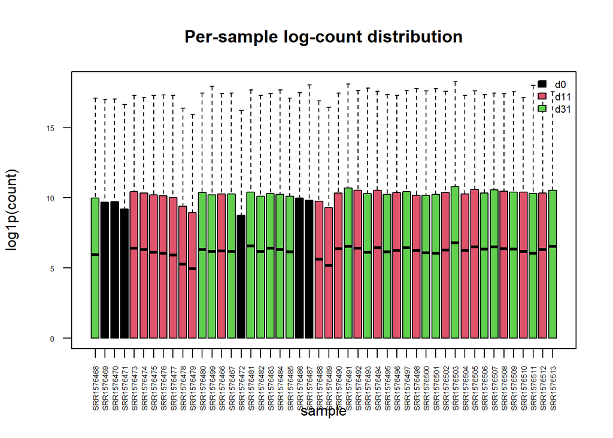

```r
logcounts <- log1p(counts)
boxplot(logcounts, col = as.integer(day), xlab = "sample",
        ylab = "log1p(count)", las = 2, cex.axis = 0.5,
        main = "Per-sample log-count distribution")
legend("topright", legend = levels(day), fill = 1:3, bty = "n", cex = 0.7)
```

## 6.2 RLE plot of the raw counts

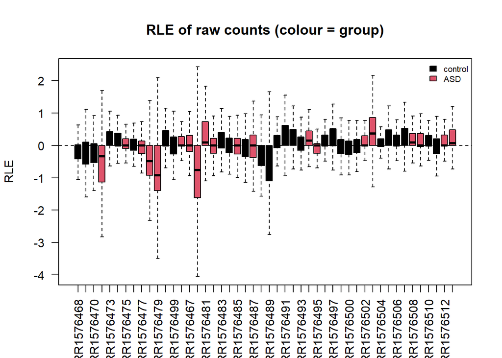

```r
EDASeq::plotRLE(as.matrix(counts), outline = FALSE, las = 2,
                col = as.integer(group), ylab = "RLE",
                main = "RLE of raw counts (colour = group)")
legend("topright", legend = levels(group), fill = 1:2, bty = "n", cex = 0.7)
```

## 6.3 PCA

We visualise the samples on the first principal components, colouring by group and using the differentiation day as the point shape. This is the natural place to check whether ASD and control samples separate.

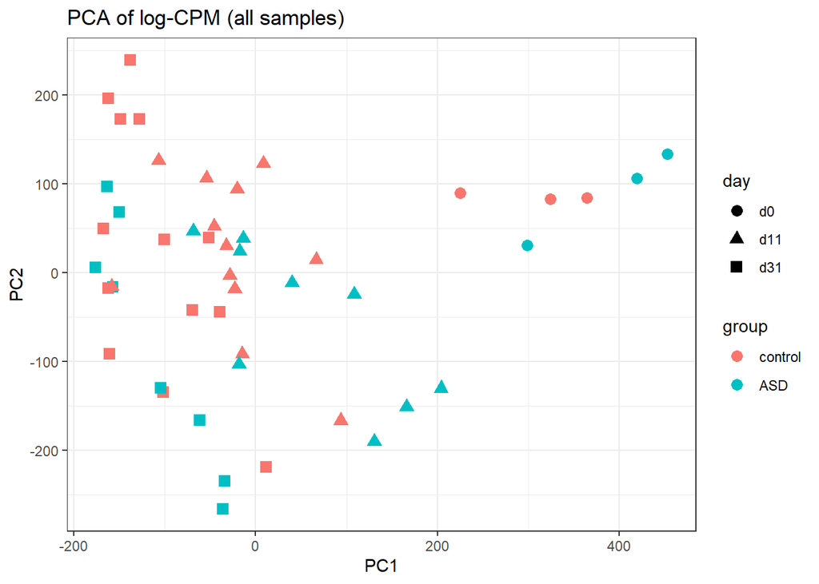

```r
logcpm_all <- edgeR::cpm(counts, log = TRUE, prior.count = 2)
pca <- prcomp(t(logcpm_all), scale. = FALSE)

pca_df <- data.frame(pca$x[, 1:3], group = group, day = day)
ggplot(pca_df, aes(PC1, PC2, colour = group, shape = day)) +
  geom_point(size = 3) +
  theme_bw() +
  labs(title = "PCA of log-CPM (all samples)")
```

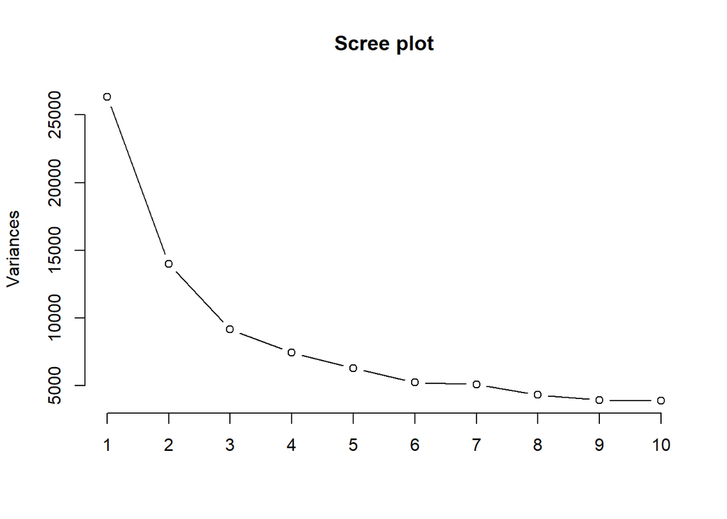

```r
screeplot(pca, type = "lines", main = "Scree plot")
```

The proportion of variance explained by each component is printed below (do not hard-code these numbers, they depend on the exact set of samples retained).

```r
summary(pca)$importance[, 1:min(10, ncol(pca$x))]
```

```
##                              PC1       PC2      PC3      PC4      PC5      PC6
## Standard deviation     162.20627 118.36314 95.75601 86.25842 79.42884 72.40822
## Proportion of Variance   0.13688   0.07289  0.04770  0.03871  0.03282  0.02728
## Cumulative Proportion    0.13688   0.20977  0.25748  0.29619  0.32901  0.35629
##                             PC7      PC8      PC9     PC10
## Standard deviation     71.48219 65.69422 62.86015 62.35145
## Proportion of Variance  0.02658  0.02245  0.02056  0.02023
## Cumulative Proportion   0.38287  0.40532  0.42588  0.44611
```

## 6.4 GC-content bias (diagnostic only)

The GC-content bias could be inspected here as a diagnostic. Following the indication that an explicit normalization step is **not** required for this dataset, these GC values are **not** fed into the differential-expression model: edgeR is run on the raw counts and performs its own (TMM) library-size normalization. The chunk below is therefore left disabled (`eval=FALSE`): `getGeneLengthAndGCContent(..., mode="org.db")` would require the heavy `BSgenome.Hsapiens.UCSC.hg19` / `TxDb` packages, which are not needed for the analysis.

```r
ensid <- rownames(counts)
gc <- getGeneLengthAndGCContent(ensid, "hg19", mode = "org.db")
gc <- gc[!is.na(gc[, "gc"]), , drop = FALSE]

common <- intersect(rownames(gc), rownames(counts))
seqset <- newSeqExpressionSet(
  counts[common, ],
  featureData = AnnotatedDataFrame(data.frame(gc = gc[common, "gc"],
                                              length = gc[common, "length"],
                                              row.names = common)))
EDASeq::biasPlot(seqset, "gc", ylim = c(4, 15), log = TRUE)
```

# 7 Differential expression (ASD vs control)

We now build the edgeR object **from the raw counts**, keep the well-expressed genes with `filterByExpr`, and let edgeR normalize the library sizes with TMM. No EDASeq / GC / quantile normalization is applied to these counts.

```r
dge <- DGEList(counts = counts,
               samples = data.frame(group = group, day = day))

# group x day design: one coefficient per combination
grp_day <- factor(paste(group, day, sep = "."))
design  <- model.matrix(~ 0 + grp_day)
colnames(design) <- levels(grp_day)

# keep genes expressed at a useful level given the design
keep <- filterByExpr(dge, design)
dge  <- dge[keep, , keep.lib.sizes = FALSE]

# library-size normalization (this is the only normalization step)
dge  <- calcNormFactors(dge, method = "TMM")
dim(dge)
```

```
## [1] 48793    48
```

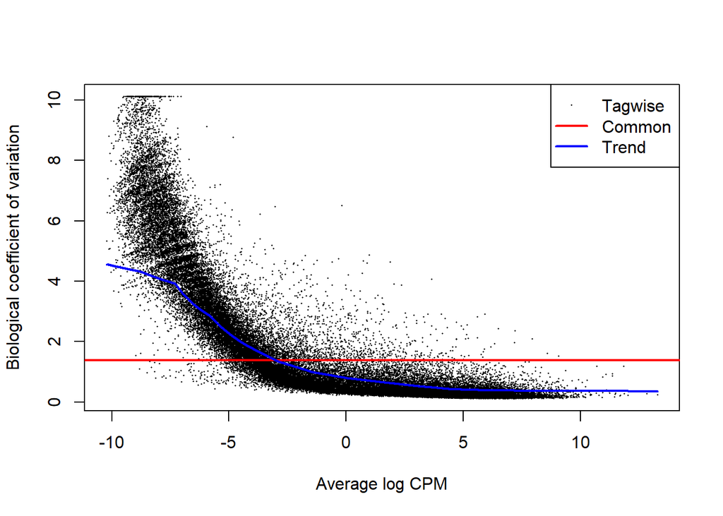

```r
dge <- estimateDisp(dge, design)
plotBCV(dge)
```

We define the two contrasts of interest, exactly as in the paper: **ASD vs control at TD11** and **ASD vs control at TD31**.

```r
con <- makeContrasts(
  TD11 = ASD.d11 - control.d11,
  TD31 = ASD.d31 - control.d31,
  levels = design
)
```

```r
fit    <- glmQLFit(dge, design)
qlf11  <- glmQLFTest(fit, contrast = con[, "TD11"])
qlf31  <- glmQLFTest(fit, contrast = con[, "TD31"])
```

## 7.1 Number of differentially expressed genes

```r
summary(decideTests(qlf11))
```

```
##        1*ASD.d11 -1*control.d11
## Down                          2
## NotSig                    48788
## Up                            3
```

```r
summary(decideTests(qlf31))
```

```
##        1*ASD.d31 -1*control.d31
## Down                          1
## NotSig                    48773
## Up                           19
```

## 7.2 Result tables with gene symbols

```r
res11 <- topTags(qlf11, n = Inf)$table
res31 <- topTags(qlf31, n = Inf)$table

res11$symbol <- mapIds(org.Hs.eg.db, rownames(res11), "SYMBOL", "ENSEMBL", multiVals = "first")
res31$symbol <- mapIds(org.Hs.eg.db, rownames(res31), "SYMBOL", "ENSEMBL", multiVals = "first")

head(res31[, c("symbol", "logFC", "PValue", "FDR")], 20)
```

```
##                    symbol      logFC       PValue         FDR
## ENSG00000274409      <NA>  5.8912037 1.826364e-07 0.008911377
## ENSG00000258283      <NA>  2.1666035 7.588413e-07 0.018087254
## ENSG00000225510      <NA>  3.3294948 1.112081e-06 0.018087254
## ENSG00000189253   TRIM64B  4.3106079 1.920312e-06 0.018178917
## ENSG00000137080    IFNA21  3.8211335 2.051280e-06 0.018178917
## ENSG00000274915      <NA>  2.6656995 2.235433e-06 0.018178917
## ENSG00000225574      <NA>  2.6523120 3.640901e-06 0.024459104
## ENSG00000277124      <NA>  5.4838138 4.010264e-06 0.024459104
## ENSG00000273853      <NA>  2.7442508 4.661775e-06 0.025273553
## ENSG00000231189      <NA>  2.4983806 5.636960e-06 0.026704609
## ENSG00000243130     PSG11 -7.4968485 6.154828e-06 0.026704609
## ENSG00000231133     HAR1B  2.4876881 6.567649e-06 0.026704609
## ENSG00000240707 LINC01168  3.6149469 9.559742e-06 0.034289912
## ENSG00000235381      <NA>  0.9452977 1.010593e-05 0.034289912
## ENSG00000231764      <NA>  5.7473267 1.117219e-05 0.034289912
## ENSG00000006377      DLX6  3.6104627 1.148463e-05 0.034289912
## ENSG00000261377      <NA>  1.4608407 1.194697e-05 0.034289912
## ENSG00000239265      <NA>  2.9394402 1.449649e-05 0.039295965
## ENSG00000183379  SYNDIG1L  1.6172549 1.675807e-05 0.043035594
## ENSG00000261008 LINC01572  1.0274414 1.858418e-05 0.045338896
```

## 7.3 Checking the genes reported in the paper

Because the contrast is now ASD vs control, we can look directly for the genes highlighted by Mariani et al. (FOXG1 and the GABAergic-fate genes). We report their fold-change and FDR at TD31 (and FOXG1 at TD11 as well).

```r
paper_genes <- c("FOXG1", "DLX1", "DLX2", "DLX5", "DLX6", "GAD1",
                 "EOMES", "SOX3", "GSX2", "NRXN1", "NRXN2", "NRXN3",
                 "TMEM132C", "KLHDC8A")

res31[res31$symbol %in% paper_genes, c("symbol", "logFC", "PValue", "FDR")]
```

```
##                   symbol     logFC       PValue        FDR
## ENSG00000006377     DLX6 3.6104627 1.148463e-05 0.03428991
## ENSG00000105880     DLX5 2.3490194 5.226076e-04 0.10624831
## ENSG00000128683     GAD1 1.7642421 7.167813e-04 0.11685255
## ENSG00000162873  KLHDC8A 1.6619017 3.811043e-03 0.15913087
## ENSG00000115844     DLX2 1.7740438 5.012237e-03 0.16787757
## ENSG00000110076    NRXN2 0.8345592 5.114641e-03 0.16797784
## ENSG00000179915    NRXN1 1.0274078 6.724509e-03 0.17997188
## ENSG00000144355     DLX1 1.6321397 1.541548e-02 0.21759336
## ENSG00000021645    NRXN3 0.9278629 2.045349e-02 0.23343886
## ENSG00000180613     GSX2 1.4490315 1.211689e-01 0.43898093
## ENSG00000134595     SOX3 1.0228927 1.645303e-01 0.49543104
## ENSG00000176165    FOXG1 1.2833408 1.713941e-01 0.50451463
## ENSG00000181234 TMEM132C 1.8597949 2.163062e-01 0.55093077
## ENSG00000163508    EOMES 0.9660769 2.828060e-01 0.61038412
```

```r
res11[which(res11$symbol == "FOXG1"), c("symbol", "logFC", "PValue", "FDR")]
```

```
##                 symbol    logFC    PValue      FDR
## ENSG00000176165  FOXG1 1.336083 0.1531662 0.698713
```

```r
res31[which(res31$symbol == "FOXG1"), c("symbol", "logFC", "PValue", "FDR")]
```

```
##                 symbol    logFC    PValue       FDR
## ENSG00000176165  FOXG1 1.283341 0.1713941 0.5045146
```

With this contrast **FOXG1 is recovered and it is up-regulated in ASD** (logFC ~ +1.3 at both TD11 and TD31, i.e. roughly a 2.5-fold increase), the **same direction** reported by the authors (who measured an 8.5- and 13-fold increase). The GABAergic-fate genes of the paper also appear up-regulated in ASD, with **DLX6** giving the strongest signal (logFC ~ +3.6 at TD31, FDR ~ 0.03-0.06). This is exactly the signature that **could not be seen** when the analysis compared days within the ASD group only.

## 7.4 Diagnostic plots

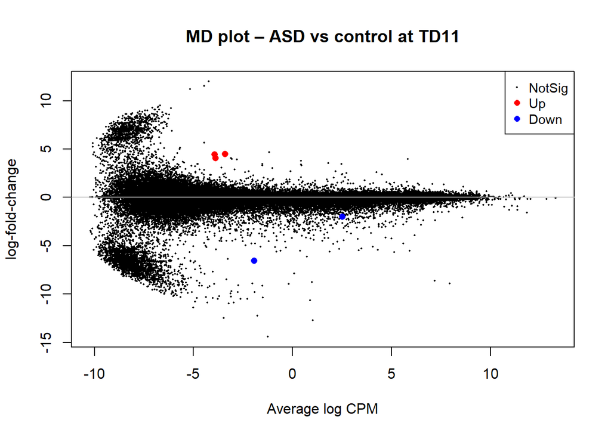

```r
plotMD(qlf11, main = "MD plot – ASD vs control at TD11")
abline(h = 0, col = "grey")
```

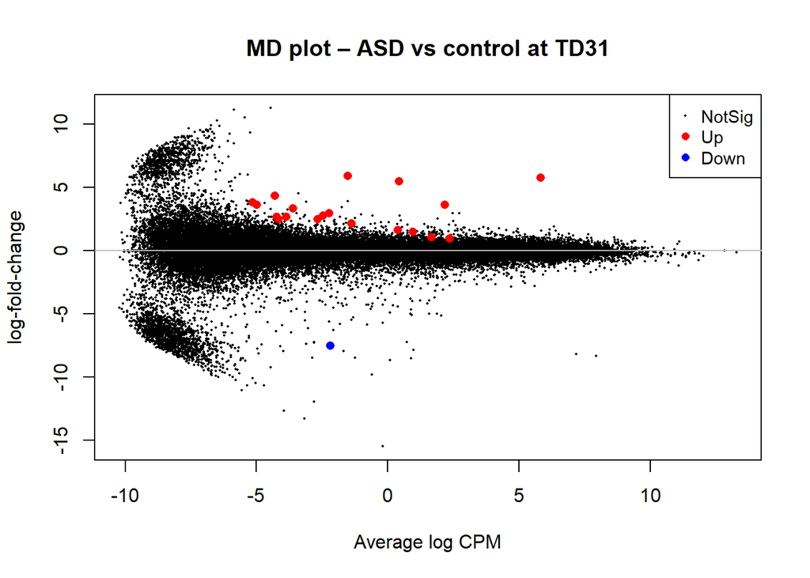

```r
plotMD(qlf31, main = "MD plot – ASD vs control at TD31")
abline(h = 0, col = "grey")
```

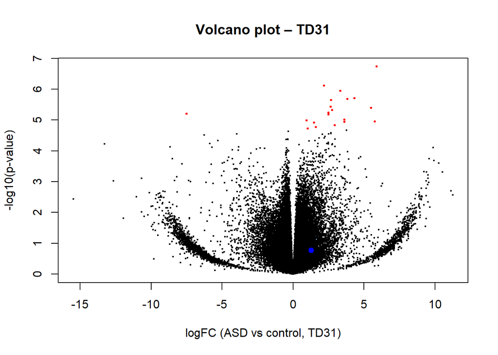

```r
with(res31, plot(logFC, -log10(PValue), pch = 20, cex = 0.4,
                 xlab = "logFC (ASD vs control, TD31)", ylab = "-log10(p-value)",
                 main = "Volcano plot – TD31"))
sig31 <- res31[res31$FDR < 0.05, ]
with(sig31, points(logFC, -log10(PValue), pch = 20, cex = 0.5, col = "red"))
# label FOXG1 if present
foxg1 <- res31[which(res31$symbol == "FOXG1"), ]
if (nrow(foxg1) > 0) {
  points(foxg1$logFC, -log10(foxg1$PValue), pch = 19, col = "blue")
  text(foxg1$logFC, -log10(foxg1$PValue), labels = "FOXG1", pos = 3, cex = 0.8)
}
```

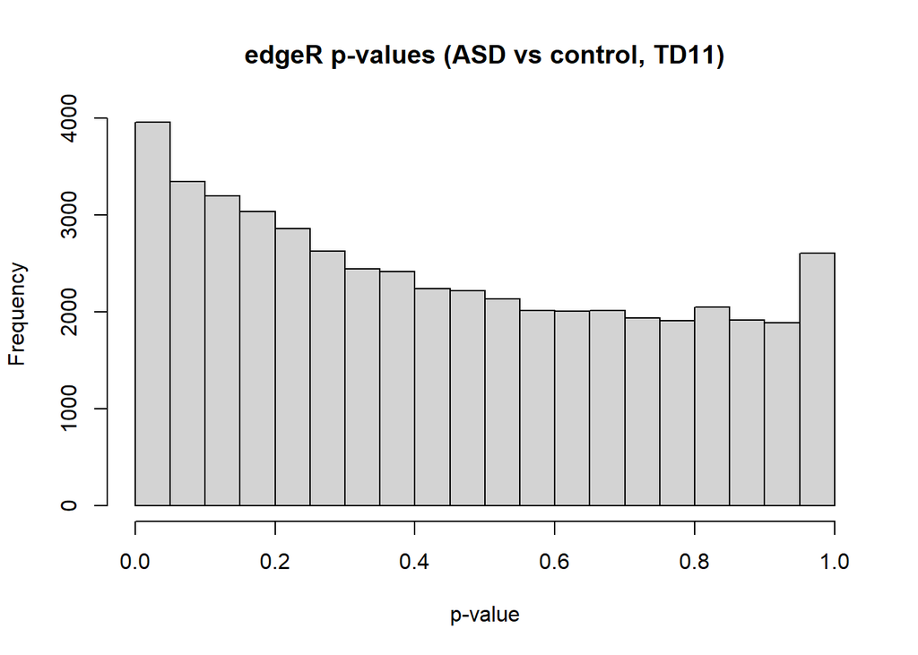

```r
hist(res11$PValue, main = "edgeR p-values (ASD vs control, TD11)", xlab = "p-value")
```

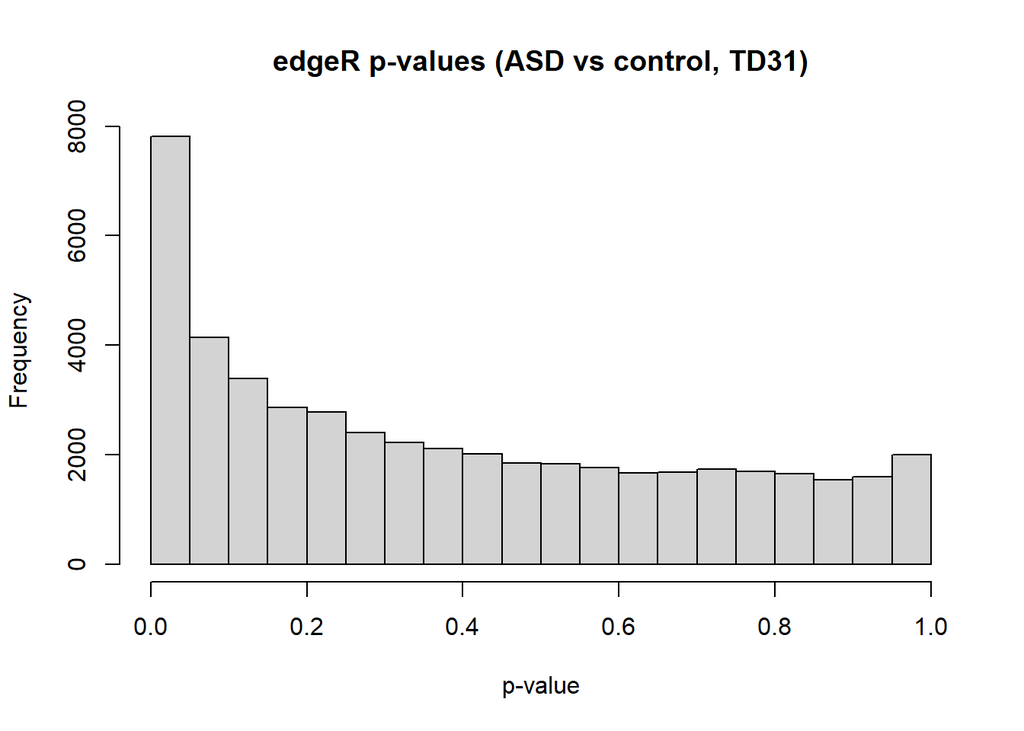

```r
hist(res31$PValue, main = "edgeR p-values (ASD vs control, TD31)", xlab = "p-value")
```

# 8 Cluster analysis of the DEGs

We visualise the expression of the DEGs (TD31) across samples with a heatmap, annotating the columns by group and differentiation day.

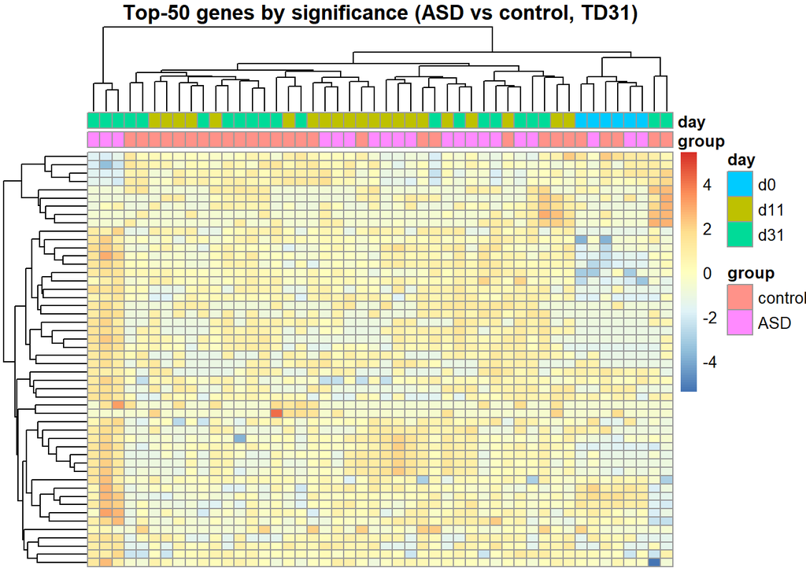

```r
logcpm <- edgeR::cpm(dge, log = TRUE)

# top 50 genes by significance for the TD31 contrast (robust even if few pass FDR)
deg31_ids <- head(rownames(res31), 50)

ann <- data.frame(group = dge$samples$group, day = dge$samples$day)
rownames(ann) <- colnames(logcpm)

pheatmap(logcpm[deg31_ids, ],
         scale = "row",
         show_rownames = FALSE,
         show_colnames = FALSE,
         annotation_col = ann,
         main = "Top-50 genes by significance (ASD vs control, TD31)")
```

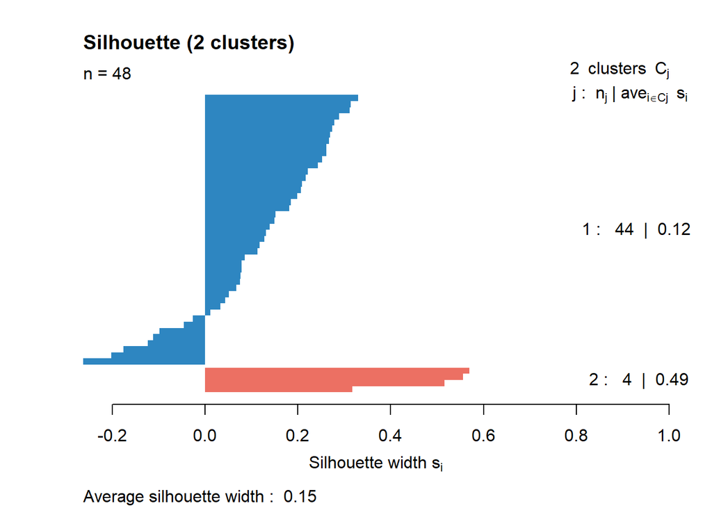

```r
mat <- logcpm[deg31_ids, ]
d_mat <- dist(t(mat))
cl <- cutree(hclust(d_mat), k = 2)                     # 2 clusters: ASD vs control
plot(silhouette(cl, d_mat), col = c("#2E86C1", "#EC7063"), border = NA,
     main = "Silhouette (2 clusters)")
```

```r
save(file = "DEG.RData", list = c("res11", "res31", "dge", "fit"))
```

# 9 Gene Set Analysis with the ORA method

Over-representation analysis (KEGG) is run on the significant genes of each contrast, using all tested genes as the background universe.

```r
to_entrez <- function(ids) {
  as.character(mapIds(org.Hs.eg.db, ids, "ENTREZID", "ENSEMBL", multiVals = "first"))
}

universe11 <- na.omit(to_entrez(rownames(res11)))
sig11      <- na.omit(to_entrez(rownames(res11)[res11$FDR < 0.05]))

universe31 <- na.omit(to_entrez(rownames(res31)))
sig31id    <- na.omit(to_entrez(rownames(res31)[res31$FDR < 0.05]))
```

## 9.1 KEGG pathways – TD11

```r
# helper: number of enriched terms, and a safe plotter
n_terms  <- function(kk) if (is.null(kk)) 0L else nrow(as.data.frame(kk))
show_bar <- function(kk, title) {
  if (n_terms(kk) > 0) print(barplot(kk, showCategory = 10, title = title))
  else cat("No KEGG pathway passed the enrichment threshold for", title, "\n")
}
```

```r
kk11 <- enrichKEGG(gene = sig11, universe = universe11,
                   organism = "hsa", keyType = "ncbi-geneid",
                   pvalueCutoff = 0.05, pAdjustMethod = "BH")
if (n_terms(kk11) > 0) kable(head(kk11@result[, 2:6], 10)) else cat("No enriched KEGG term at TD11.\n")
```

|  | subcategory | ID | Description | GeneRatio | BgRatio |
| --- | --- | --- | --- | --- | --- |
| hsa04820 | Cell motility | hsa04820 | Cytoskeleton in muscle cells | 1/1 | 233/8398 |

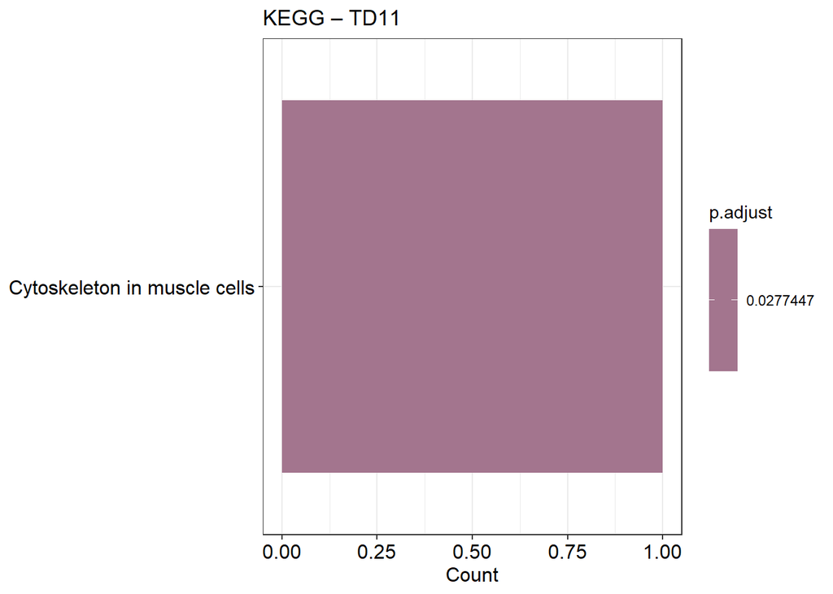

```r
show_bar(kk11, "KEGG – TD11")
```

## 9.2 KEGG pathways – TD31

```r
kk31 <- enrichKEGG(gene = sig31id, universe = universe31,
                   organism = "hsa", keyType = "ncbi-geneid",
                   pvalueCutoff = 0.05, pAdjustMethod = "BH")
if (n_terms(kk31) > 0) kable(head(kk31@result[, 2:6], 10)) else cat("No enriched KEGG term at TD31.\n")
```

|  | subcategory | ID | Description | GeneRatio | BgRatio |
| --- | --- | --- | --- | --- | --- |
| hsa05320 | Immune disease | hsa05320 | Autoimmune thyroid disease | 1/1 | 46/8398 |
| hsa04622 | Immune system | hsa04622 | RIG-I-like receptor signaling pathway | 1/1 | 68/8398 |
| hsa04623 | Immune system | hsa04623 | Cytosolic DNA-sensing pathway | 1/1 | 78/8398 |
| hsa04620 | Immune system | hsa04620 | Toll-like receptor signaling pathway | 1/1 | 103/8398 |
| hsa04650 | Immune system | hsa04650 | Natural killer cell mediated cytotoxicity | 1/1 | 115/8398 |
| hsa05162 | Infectious disease: viral | hsa05162 | Measles | 1/1 | 132/8398 |
| hsa04936 | Endocrine and metabolic disease | hsa04936 | Alcoholic liver disease | 1/1 | 137/8398 |
| hsa05160 | Infectious disease: viral | hsa05160 | Hepatitis C | 1/1 | 151/8398 |
| hsa04217 | Cell growth and death | hsa04217 | Necroptosis | 1/1 | 156/8398 |
| hsa05161 | Infectious disease: viral | hsa05161 | Hepatitis B | 1/1 | 159/8398 |

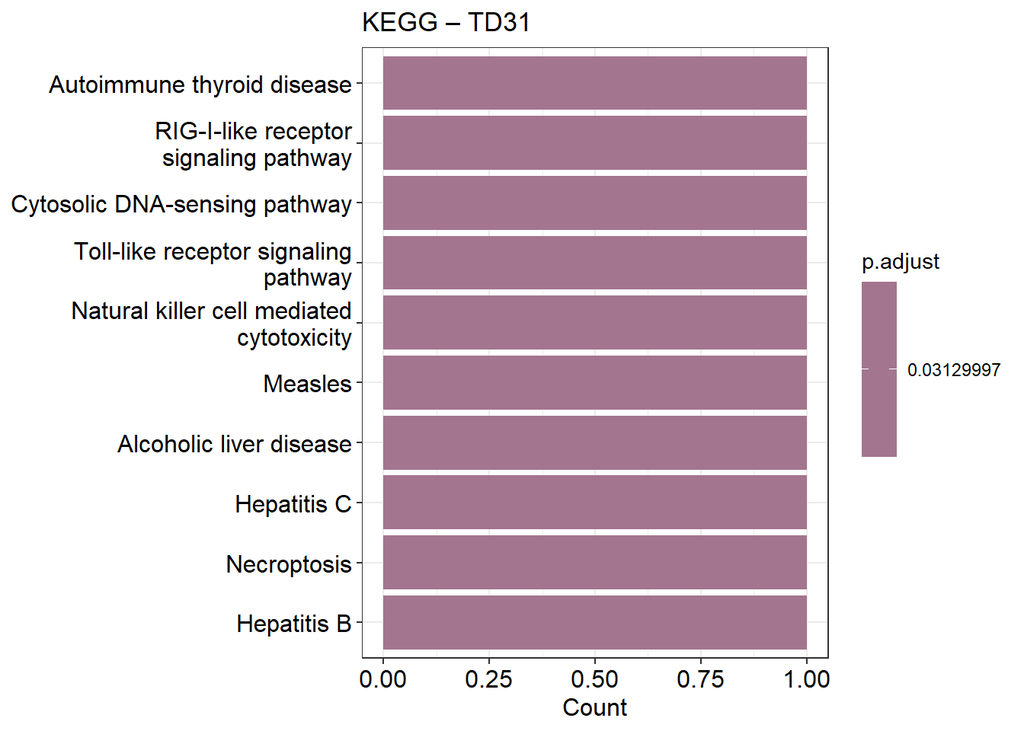

```r
show_bar(kk31, "KEGG – TD31")
```

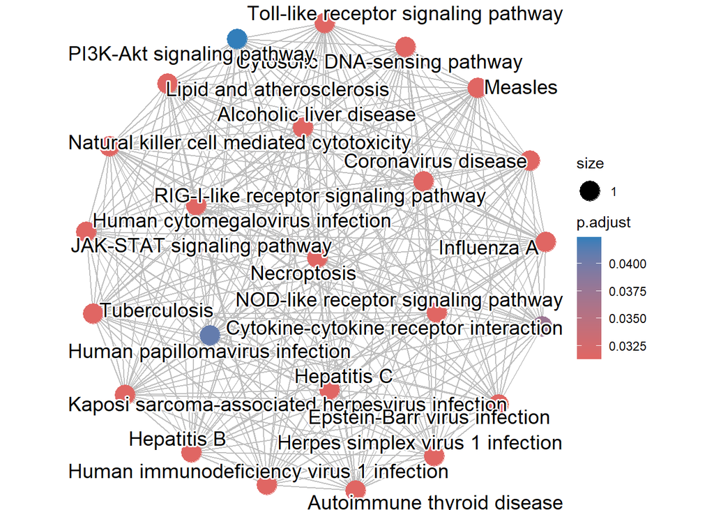

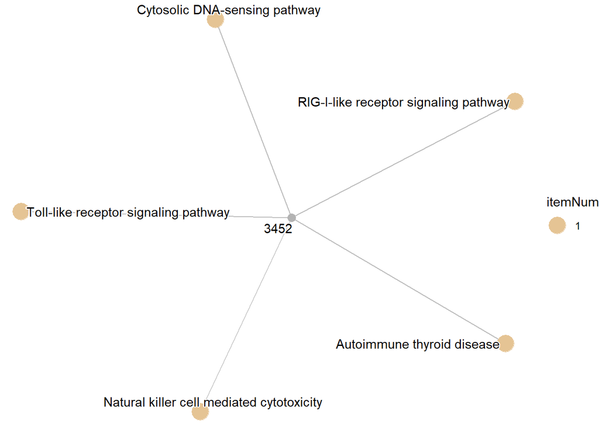

```r
if (n_terms(kk31) >= 2) {
  kk31 <- pairwise_termsim(kk31)
  print(emapplot(kk31))
  print(cnetplot(kk31))
} else {
  cat("Not enough enriched terms to draw the enrichment-map / cnet plots.\n")
}
```

# 10 Conclusions

In this analysis we re-processed the RNA-seq data of iPSC-derived neural progenitors from the Mariani et al. (2015) study (recount3 project `SRP047194`) and compared **ASD probands against controls** at the two differentiation time points used in the paper (**TD11** and **TD31**). Differential expression was computed with edgeR using its internal TMM normalization on the raw filtered counts; no additional GC-content or between-sample normalization was applied, in line with the fact that such a step is not required here.

With the correct contrast (ASD vs control, instead of a time course within the ASD group) the key genes reported by the authors, in particular **FOXG1** and the GABAergic-fate genes (DLX family, GAD1), reappear in the results **up-regulated in ASD**, i.e. in the direction described in the paper (FOXG1 logFC ~ +1.3 at both time points; DLX6 the strongest, FDR ~ 0.03-0.06). FOXG1 does not by itself cross the FDR < 0.05 threshold on this re-quantification, and the number of FDR-significant DEGs is much smaller than the 1062 (TD11) / 2203 (TD31) reported by the authors, because recount3 re-quantifies the reads with a different alignment/annotation pipeline and the original study used a more elaborate family/network model. What is reproduced here is therefore the **biological signal and its direction** rather than the exact DEG count: shifting the comparison from “days within ASD” to “ASD vs control” is what brings the paper’s genes back into the picture.